# Statistical Analysis with R

## Content

1. Importing data
2. Tidying data
3. Joining data

## Importing data

## First step in data analysis

How do you get your data in workspace?

- data in R packages
- data from other sources
  - different formats (e.g. csv, sav, txt, excel)
  - from internet

## Data from R packages

Many R packages contain data:

- type `data()`, place the cursor between the parentheses, and hit TAB
  - the pop-up menu shows all datasets in the loaded packages
  - get more info with `help(<data>, package = <package>)`

[figure not shown]

## Interactively importing data

- text files (comma-, tab-, space-delimited)
- data files from other statistical programs (SPSS, SAS, Stata)
- excel files (.xls, .xlsx)

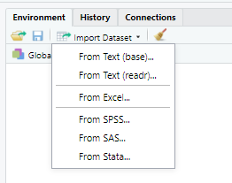

## Import `csv` from link

Interactively import `mtcars` data in `CSV` format via the link:

- https://surfdrive.surf.nl/files/index.php/s/8d2PoYlPZY9xcQA/download

[figure not shown]

## Import `sav` from link

Interactively import the file `mtcars.sav` via:

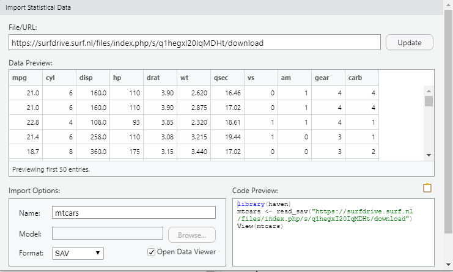

What is the difference with the previous data set?

## Joining data sets

## Functions for joining data

Data frames joined by `"x1"`

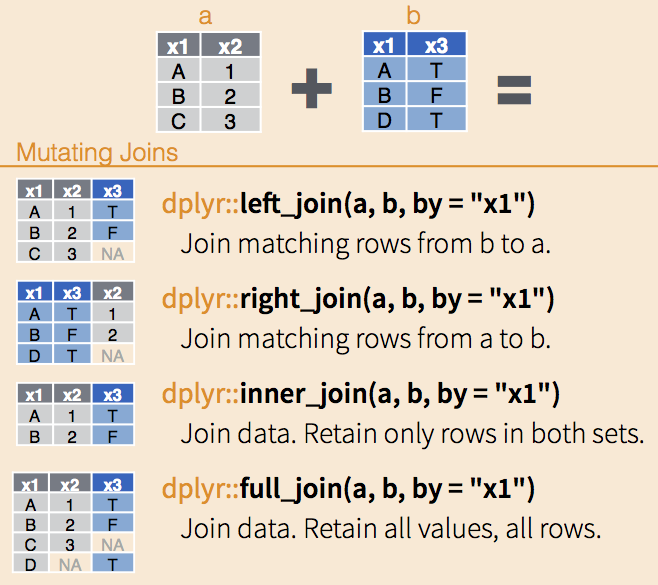

## Houseprices and gdp

Download the `csv` data sets and import in workspace

- [houseprices](https://surfdrive.surf.nl/files/index.php/s/SOcPB7CGQb8BCa3/download)
- [gdp](https://surfdrive.surf.nl/files/index.php/s/UaFWgppDUapxxO0/dowwnload)

Example code for the `houseprices` data:

```r
library(readr)
hp <- read_csv("houseprices.csv",
               n_max = 27,
               skip = 1,
               col_names = c("country", "houseprice"),
               show_col_types = F)
```

Check if you understand the code

## The result

[output not shown]

## Join `housesprices` and `gdp`

Display a summary of both data sets

Depending on the result, join the data on `country` with

- `full_join()`
- `left_join()` or `right_join()`
- `inner_join()`

given that you do not want missing values in the new data set.

## Tydying data

## Concept of tidy data

Tidyverse is developed for *tidy* data:

- variables measuring the same thing form a single variable

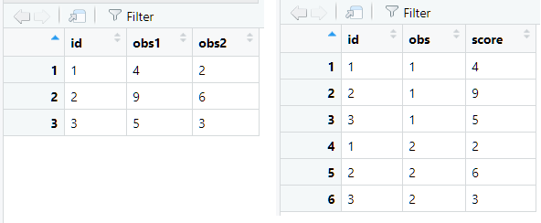

- untidy versus tidy data

## Pivoting

The function to tidy data (in its simplest form) is:

```r
pivot_longer(data, cols, names_to, names_prefix, values_to)
```

- `data` the untidy data set
- `cols`, columns to pivot
- `names_to` name of the new variable
- `names_prefix` separate the name and number of the columns to pivot
- `values_to` name of the variable with the values

## Example

```r
(df <- data.frame(id = 1:3, obs1 = c(4, 9,5), obs2 = c(2, 6, 4)))
  id obs1 obs2
1  1    4    2
2  2    9    6
3  3    5    4

pivot_longer(df, cols = -id,
             names_to = "obs",
             names_prefix ="obs",
             values_to = "score")
# A tibble: 6 × 3
     id obs   score
  <int> <chr> <dbl>
1     1 1         4
2     1 2         2
3     2 1         9
4     2 2         6
5     3 1         5
6     3 2         4
```